# Deputies Expenditure Analysis: My Questions

Jose Manoel Ferreira

# Deputies Expenditure Analysis: My Questions

## Introduction

The present work is a continuation of https://rpubs.com/manoelf/416750

Here we are going to create new questions and answer it through the data analysis. The data about deputies expenses is located right [here](https://canvas.instructure.com/courses/1402758/files/67618888/download?verifier=ibyou5PYo9aaFgRaefc0keYkHhkQ2EqIArdmI1bq&wrap=1) and more informations about you can find in [government website](http://www2.camara.leg.br/transparencia/acesso-a-informacao/copy_of_perguntas-frequentes/cota-para-o-exercicio-da-atividade-parlamentar)

#### Set Up

For our analisys we need the folowing packages to be installed.

```r
#install.packages("ggplot2")
#install.packages("dplyr")
#install.packages("tidyr")
#install.packages("scales")
#install.packages("plotly")
```

Once packages installed we load it.

```r
library(ggplot2)
library(dplyr)
library(tidyr)
library(scales)
library(plotly)
```

Setting up the workspace.

Now we gonna load the main data, which is about the deputies expenses.

```r
data <- read.csv(("data/dadosCEAP.csv"))
```

### It is important to know how much money is expende along the months, for that reason we will se it through the graphic.

First we need to create two new column which represents the year of the expense and its month.

Once the column are created we will agroup and sum all values expend in each month.

Lets see the expense in a graphic.

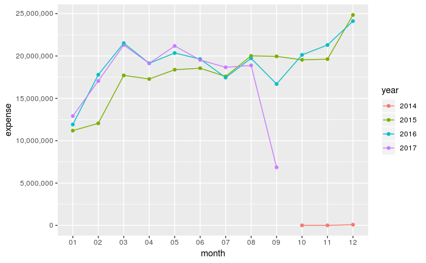

### What about the average of money expended by the deputies in thir groups?

In order to know the answer to that question, we should know how many deputies have by grups. So we gonna count the deputies by grouping the grups sigle and the depuite name.

| sgPartido | total_deputies |
| --- | --- |
| PRTB | 1 |
| PTdoB | 1 |
| PEN | 3 |
| PMN | 3 |
| PRP | 3 |
| PSL | 4 |
| REDE | 4 |
| AVANTE | 6 |
| PSOL | 6 |
| PHS | 7 |

[output cut: 19 more lines]

Now we need to know how much money each group have expended. We know it by gruping all grups and doing a sum of all expenses. Then we got it:

```r
expense_by_group <- data %>%
  group_by(sgPartido) %>%
  filter(valorLíquido >= 0) %>%
  summarise(expense = sum(valorLíquido))

expense_by_group
```

[output not shown]

Now we put all together and do the average by dividing the group expenses by its total of deputies. Once we have it done, lets see a bar graphic whit that information.

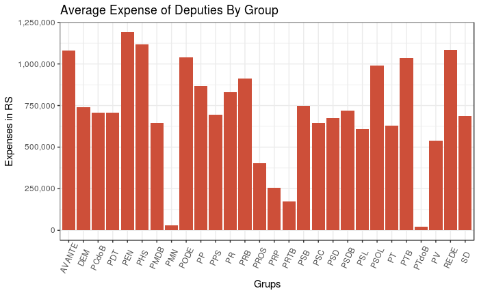

That’s perfect! Now clear we have the average and seeing it is better to understand.

So the grup that have the minimum average is PTdoB whit an expende of RS 22505.34 and 1 member so its average is RS 22505.34. And the one who has expended more is PEN, all expense get a total of RS 3572566.55, 3 member and a average of RS 1190855.52.